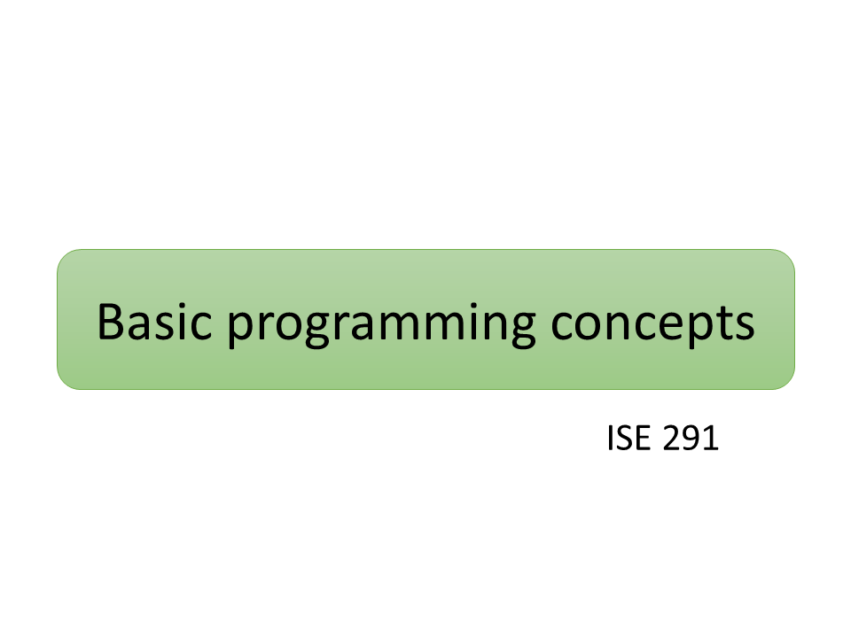

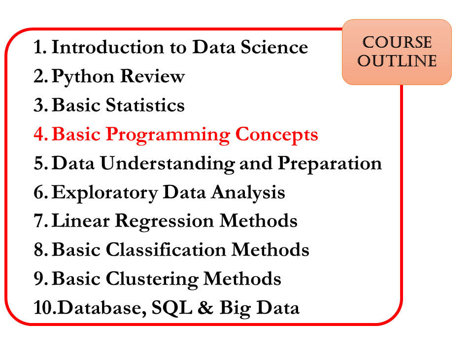

# Basic Programming

> 📌 Python Programming and DataFrames

## Python Programming

1. In ICS 104, we have seen Python as a general purpose programming language.
2. Although, Python can be used in many areas that require programming, in this chapter we see the usage of Python w.r.t data reading and visualization.
3. Specifically, we highlight the usage of Pandas and Seaborn library.

## Learning Outcomes

1. Build, read and/or manipulate DataFrames.
2. Learn DataFrame slicing, sorting and selection methods.
3. Visualize data using histogram, box plots, scatter plots, etc.

## Data Series

1. In Pandas, series are labeled/indexed one-dimensional arrays.
2. The elements of the series could be integer, float, string, objects, etc.
3. The index may not be unique.
4. A collection of Data Series is called as Data Frame.
5. Our focus in this chapter will be on Data Frames.

# DataFrame (DF)

> 📌 Collection of series, where each column is a series.

## Creating DataFrame

In order to create a data from, following things are typically needed:

1. Data in n-dimensional array format.
2. Optional column title/header

An optional row index can be given too. In addition to the above, there are many parameters, which can be read from pydata docs.

### Create DF with Given n-D Array

Data:  
\begin{equation}\begin{bmatrix} a11 & a12\\ a21 & a22 \end{bmatrix} \end{equation} col_names: ['col 1', 'col 2']  
row_index: ['row 1', 'row 2']

```python
import pandas as pd
df = pd.DataFrame([['a11', 'a12'], ['a21', 'a22']],
                  index=['row 1', 'row 2'],
                  columns=['col 1', 'col 2'])

display(df)
```

|  | col 1 | col 2 |
| --- | --- | --- |
| row 1 | a11 | a12 |
| row 2 | a21 | a22 |

### Create DF with Random n-D Array

Data: random 3 columns 1000 rows numbers between 0 and 1.  
col_names: ['col 1', 'col 2', 'col 3']

```python
import pandas as pd
import numpy as np

df = pd.DataFrame(np.random.rand(1000,3),
                  columns=['col 1', 'col 2', 'col 3'])

display(df)
```

|  | col 1 | col 2 | col 3 |
| --- | --- | --- | --- |
| 0 | 0.900379 | 0.450864 | 0.915527 |
| 1 | 0.107990 | 0.368869 | 0.516130 |
| 2 | 0.342405 | 0.492546 | 0.788363 |
| 3 | 0.597415 | 0.860259 | 0.241468 |
| 4 | 0.095641 | 0.791185 | 0.959279 |
| ... | ... | ... | ... |
| 995 | 0.247713 | 0.397768 | 0.911072 |
| 996 | 0.023047 | 0.423800 | 0.863465 |
| 997 | 0.714096 | 0.294497 | 0.737279 |
| 998 | 0.494320 | 0.450755 | 0.293238 |
| 999 | 0.552515 | 0.312760 | 0.456961 |

1000 rows × 3 columns

### Create DF from CSV

Data: Basic-1.csv  
col_names: Use from the first row

1. Display the above data.
2. Obtain the summary statistics:
   - For numeric data (count, mean, std, min, max)
   - For non-numeric data (count, unique-values, most occurring and its frequency)

```python
#1. Display the above data.
import pandas as pd
df = pd.read_csv('data/Basic-1.csv', delimiter=',')#the path to the data file.

## Path relative to the .ipynb file
# df = pd.read_csv('Basic-101.csv', delimiter=',',header=None,names=['Gender','Job Type',"Province"])

# display data
display(df)

#2. Obtain the summary statistics:
# summary statistics for non-numeric columns is available by default only when all columns are non-numeric
display(df.describe())
```

|  | Gender | Job Type | Province |
| --- | --- | --- | --- |
| 0 | M | Pink-collar | Hejaz |
| 1 | M | White-collar | Central |
| 2 | M | Pink-collar | Hejaz |
| 3 | M | Pink-collar | Hejaz |
| 4 | M | Gold-collar | Eastern |
| ... | ... | ... | ... |
| 1273 | M | Blue-collar | Central |
| 1274 | M | Pink-collar | Hejaz |
| 1275 | F | Blue-collar | Hejaz |
| 1276 | F | White-collar | Central |
| 1277 | F | Blue-collar | Eastern |

1278 rows × 3 columns

|  | Gender | Job Type | Province |
| --- | --- | --- | --- |
| count | 1278 | 1278 | 1278 |
| unique | 2 | 4 | 3 |
| top | M | White-collar | Central |
| freq | 875 | 568 | 531 |

### Create DF from XLSX

For the above data, do the following:

1. Display the above data.
2. Obtain the summary statistics:
   - For numeric data (count, mean, std, min, max)
   - For non-numeric data (count, unique-values, most occurring and its frequency)

```python
# 1. Display the above data.
import pandas as pd

df = pd.read_excel('data/Basic-2.xlsx')

display(df.head())  # df.tail(), df.sample(5)
```

|  | c1 | c2 | c3 | c4 | c5 | c6 | c7 | c8 | c9 | c10 | c11 | c12 | c13 | c14 | c15 | c16 | c17 |
| --- | --- | --- | --- | --- | --- | --- | --- | --- | --- | --- | --- | --- | --- | --- | --- | --- | --- |
| 0 | 1.0 | 5.0 | NaN | NaN | NaN | 40.0 | NaN | NaN | 2.0 | NaN | 11.0 | average | NaN | NaN | yes | NaN | good |
| 1 | 2.0 | 4.5 | 5.8 | NaN | NaN | 35.0 | ret_allw | NaN | NaN | yes | 11.0 | below average | NaN | full | NaN | full | good |
| 2 | NaN | NaN | NaN | NaN | NaN | 38.0 | empl_contr | NaN | 5.0 | NaN | 11.0 | generous | yes | half | yes | half | good |
| 3 | 3.0 | 3.7 | 4.0 | 5.0 | tc | NaN | NaN | NaN | NaN | yes | NaN | NaN | NaN | NaN | yes | NaN | good |
| 4 | 3.0 | 4.5 | 4.5 | 5.0 | NaN | 40.0 | NaN | NaN | NaN | NaN | 12.0 | average | NaN | half | yes | half | good |

```python
# 2. Obtain the summary statistics:

display(df.describe())
# by default the describe gives summary of the numeric columns, when there are mixed columns
# df.describe(include='all') # can be used, but too many NaNs
```

|  | c1 | c2 | c3 | c4 | c6 | c8 | c9 | c11 |
| --- | --- | --- | --- | --- | --- | --- | --- | --- |
| count | 39.000000 | 39.000000 | 30.000000 | 12.000000 | 37.000000 | 7.000000 | 24.000000 | 38.000000 |
| mean | 2.102564 | 3.620513 | 3.913333 | 3.766667 | 37.810811 | 6.142857 | 4.583333 | 11.105263 |
| std | 0.753758 | 1.331438 | 1.280822 | 1.415070 | 2.716593 | 4.845223 | 4.754098 | 1.371318 |
| min | 1.000000 | 2.000000 | 2.000000 | 2.000000 | 27.000000 | 2.000000 | 0.000000 | 9.000000 |
| 25% | 2.000000 | 2.500000 | 2.625000 | 2.250000 | 37.000000 | 2.000000 | 3.000000 | 10.000000 |
| 50% | 2.000000 | 3.500000 | 4.000000 | 4.600000 | 38.000000 | 4.000000 | 4.000000 | 11.000000 |
| 75% | 3.000000 | 4.500000 | 4.500000 | 5.000000 | 40.000000 | 10.000000 | 5.000000 | 12.000000 |
| max | 3.000000 | 6.900000 | 7.000000 | 5.100000 | 40.000000 | 13.000000 | 25.000000 | 15.000000 |

```python
# to get summary of non-numeric columns

# Idenfity non-numeric columns
cat_columns= df.select_dtypes(include='object').columns

# Show summary of non-numeric columns
df[cat_columns].describe()

## or in one step
# df.select_dtypes(include='object').describe()
```

|  | c5 | c7 | c10 | c12 | c13 | c14 | c15 | c16 | c17 |
| --- | --- | --- | --- | --- | --- | --- | --- | --- | --- |
| count | 24 | 18 | 18 | 37 | 16 | 25 | 20 | 24 | 40 |
| unique | 3 | 3 | 2 | 3 | 2 | 3 | 2 | 3 | 2 |
| top | none | none | no | below average | yes | half | yes | full | good |
| freq | 14 | 8 | 11 | 14 | 11 | 11 | 18 | 12 | 26 |

## Accessing Elements

*.loc* and *.iloc* methods can be used for accessing the elements of a DF.

### Accessing via .loc

Consider the dataset given in Basic-1.csv. Display second row, second column element.

```python
import pandas as pd
df = pd.read_csv('data/Basic-1.csv', delimiter=',')
print(df.loc[1,'Job Type'])
```

```
White-collar
```

### Accessing via .iloc

Consider the dataset given in Basic-1.csv. Display second row, second column element.

```python
import pandas as pd
df = pd.read_csv('data/Basic-1.csv', delimiter=',')
display(df.head())
print(df.iloc[1,1])
print(df.loc[1,'Job Type'])
```

|  | Gender | Job Type | Province |
| --- | --- | --- | --- |
| 0 | M | Pink-collar | Hejaz |
| 1 | M | White-collar | Central |
| 2 | M | Pink-collar | Hejaz |
| 3 | M | Pink-collar | Hejaz |
| 4 | M | Gold-collar | Eastern |

```
White-collar
White-collar
```

## DF Slicing

1. Slicing is nothing but extracting a part of the DF.
2. The part could be contiguous or broken chunks of the DF.

### Single Column Slice

A single column can be extracted using the following methods:

1. df.COL_NAME
2. df[COL_NAME]

Consider the dataset given in Basic-2.xlsx. Display first column.

```python
import pandas as pd

df = pd.read_excel('data/Basic-2.xlsx')
# df.head()
display(df['c1'])

## Other styles to select a column
# display(df.iloc[:,0])
# display(df.loc[:,'c1'])

## Following code can be used to create column names when dataset does not contain any column names.
# col_name=[''.join(['c',str(i+1)])  for i in range(17)]
## Following options can be used to add column names to the dataset
# header=None, names=col_name
```

```
0     1.0
1     2.0
2     NaN
3     3.0
4     3.0
5     2.0
6     3.0
7     3.0
8     2.0
9     1.0
10    3.0
11    2.0
12    2.0
13    3.0
14    1.0
```

[output cut: 26 more lines]

### Slicing via .loc

Consider the dataset given in Basic-2.xlsx. Display first 10 rows from the second, third, fourth and fifth column.

```python
import pandas as pd
df = pd.read_excel('data/Basic-2.xlsx')

display(df.head())

display(df.loc[0:9,'c2':'c5'])  # ends are inclusive

# display(df.loc[0:9:2,'c2':'c5':2])  # ends are inclusive and steps can be used too
```

|  | c1 | c2 | c3 | c4 | c5 | c6 | c7 | c8 | c9 | c10 | c11 | c12 | c13 | c14 | c15 | c16 | c17 |
| --- | --- | --- | --- | --- | --- | --- | --- | --- | --- | --- | --- | --- | --- | --- | --- | --- | --- |
| 0 | 1.0 | 5.0 | NaN | NaN | NaN | 40.0 | NaN | NaN | 2.0 | NaN | 11.0 | average | NaN | NaN | yes | NaN | good |
| 1 | 2.0 | 4.5 | 5.8 | NaN | NaN | 35.0 | ret_allw | NaN | NaN | yes | 11.0 | below average | NaN | full | NaN | full | good |
| 2 | NaN | NaN | NaN | NaN | NaN | 38.0 | empl_contr | NaN | 5.0 | NaN | 11.0 | generous | yes | half | yes | half | good |
| 3 | 3.0 | 3.7 | 4.0 | 5.0 | tc | NaN | NaN | NaN | NaN | yes | NaN | NaN | NaN | NaN | yes | NaN | good |
| 4 | 3.0 | 4.5 | 4.5 | 5.0 | NaN | 40.0 | NaN | NaN | NaN | NaN | 12.0 | average | NaN | half | yes | half | good |

|  | c2 | c3 | c4 | c5 |
| --- | --- | --- | --- | --- |
| 0 | 5.0 | NaN | NaN | NaN |
| 1 | 4.5 | 5.8 | NaN | NaN |
| 2 | NaN | NaN | NaN | NaN |
| 3 | 3.7 | 4.0 | 5.0 | tc |
| 4 | 4.5 | 4.5 | 5.0 | NaN |
| 5 | 2.0 | 2.5 | NaN | NaN |
| 6 | 4.0 | 5.0 | 5.0 | tc |
| 7 | 6.9 | 4.8 | 2.3 | NaN |
| 8 | 3.0 | 7.0 | NaN | NaN |
| 9 | 5.7 | NaN | NaN | none |

### Slicing via .iloc

Consider the dataset given in Basic-2.xlsx. Display first 10 rows from the second, third, fourth and fifth column.

```python
import pandas as pd
df = pd.read_excel('data/Basic-2.xlsx')

display(df.iloc[:10,1:5])
```

|  | c2 | c3 | c4 | c5 |
| --- | --- | --- | --- | --- |
| 0 | 5.0 | NaN | NaN | NaN |
| 1 | 4.5 | 5.8 | NaN | NaN |
| 2 | NaN | NaN | NaN | NaN |
| 3 | 3.7 | 4.0 | 5.0 | tc |
| 4 | 4.5 | 4.5 | 5.0 | NaN |
| 5 | 2.0 | 2.5 | NaN | NaN |
| 6 | 4.0 | 5.0 | 5.0 | tc |
| 7 | 6.9 | 4.8 | 2.3 | NaN |
| 8 | 3.0 | 7.0 | NaN | NaN |
| 9 | 5.7 | NaN | NaN | none |

```python
## Example of loc and iloc
df = pd.DataFrame([['a11', 'a12'], ['a21', 'a22']],
                  index=['row 1', 'row 2'],
                  columns=['col 1', 'col-2'])

display(df)


# display(df.loc[:,'col 1'])  # Select one column

# display(df['col 1'])  # Select one column

# display(df.col-2) # # Select one column, problem is Spaces or Special characters

# display(df.loc['row 2','col 1'])

# display(df.loc['row 2',:])

# display(df['row 2']) ## check...


# display(df.iloc[:,0])  # Select one column

# display(df.iloc[1,0]) # row 2 column 1
```

|  | col 1 | col-2 |
| --- | --- | --- |
| row 1 | a11 | a12 |
| row 2 | a21 | a22 |

## DF Sorting

1. DataFrames can be sorted w.r.t values in the columns.
2. One or more columns can be used for sorting.

Consider the dataset given in Basic-2.xlsx. Sort the rows according to the first column, in ascending order. Repeat the sort in descending order.

```python
import pandas as pd

#Read data
df = pd.read_excel('data/Basic-2.xlsx')
display(df.head())

# # sort by single column in ascending order
df.sort_values(by=['c1'], inplace=True)
display(df.head())

# # sort by single column in descending order
df.sort_values(by=['c1'], inplace=True, ascending=False)
display(df.head())
```

|  | c1 | c2 | c3 | c4 | c5 | c6 | c7 | c8 | c9 | c10 | c11 | c12 | c13 | c14 | c15 | c16 | c17 |
| --- | --- | --- | --- | --- | --- | --- | --- | --- | --- | --- | --- | --- | --- | --- | --- | --- | --- |
| 0 | 1.0 | 5.0 | NaN | NaN | NaN | 40.0 | NaN | NaN | 2.0 | NaN | 11.0 | average | NaN | NaN | yes | NaN | good |
| 1 | 2.0 | 4.5 | 5.8 | NaN | NaN | 35.0 | ret_allw | NaN | NaN | yes | 11.0 | below average | NaN | full | NaN | full | good |
| 2 | NaN | NaN | NaN | NaN | NaN | 38.0 | empl_contr | NaN | 5.0 | NaN | 11.0 | generous | yes | half | yes | half | good |
| 3 | 3.0 | 3.7 | 4.0 | 5.0 | tc | NaN | NaN | NaN | NaN | yes | NaN | NaN | NaN | NaN | yes | NaN | good |
| 4 | 3.0 | 4.5 | 4.5 | 5.0 | NaN | 40.0 | NaN | NaN | NaN | NaN | 12.0 | average | NaN | half | yes | half | good |

|  | c1 | c2 | c3 | c4 | c5 | c6 | c7 | c8 | c9 | c10 | c11 | c12 | c13 | c14 | c15 | c16 | c17 |
| --- | --- | --- | --- | --- | --- | --- | --- | --- | --- | --- | --- | --- | --- | --- | --- | --- | --- |
| 0 | 1.0 | 5.0 | NaN | NaN | NaN | 40.0 | NaN | NaN | 2.0 | NaN | 11.0 | average | NaN | NaN | yes | NaN | good |
| 16 | 1.0 | 2.8 | NaN | NaN | NaN | 35.0 | NaN | NaN | 2.0 | NaN | 12.0 | below average | NaN | NaN | NaN | NaN | good |
| 14 | 1.0 | 3.0 | NaN | NaN | none | 36.0 | NaN | NaN | 10.0 | no | 11.0 | generous | NaN | NaN | NaN | NaN | good |
| 24 | 1.0 | 6.0 | NaN | NaN | NaN | 38.0 | NaN | 8.0 | 3.0 | NaN | 9.0 | generous | NaN | NaN | NaN | NaN | good |
| 17 | 1.0 | 2.1 | NaN | NaN | tc | 40.0 | ret_allw | 2.0 | 3.0 | no | 9.0 | below average | yes | half | NaN | none | bad |

|  | c1 | c2 | c3 | c4 | c5 | c6 | c7 | c8 | c9 | c10 | c11 | c12 | c13 | c14 | c15 | c16 | c17 |
| --- | --- | --- | --- | --- | --- | --- | --- | --- | --- | --- | --- | --- | --- | --- | --- | --- | --- |
| 29 | 3.0 | 2.0 | 2.5 | NaN | NaN | 35.0 | none | NaN | NaN | NaN | 10.0 | average | NaN | NaN | yes | full | bad |
| 7 | 3.0 | 6.9 | 4.8 | 2.3 | NaN | 40.0 | NaN | NaN | 3.0 | NaN | 12.0 | below average | NaN | NaN | NaN | NaN | good |
| 3 | 3.0 | 3.7 | 4.0 | 5.0 | tc | NaN | NaN | NaN | NaN | yes | NaN | NaN | NaN | NaN | yes | NaN | good |
| 4 | 3.0 | 4.5 | 4.5 | 5.0 | NaN | 40.0 | NaN | NaN | NaN | NaN | 12.0 | average | NaN | half | yes | half | good |
| 34 | 3.0 | 2.0 | 2.5 | 2.1 | tc | 40.0 | none | 2.0 | 1.0 | no | 10.0 | below average | no | half | yes | full | bad |

Consider the dataset given in Basic-2.xlsx. Sort the rows according to the first and then sixth column, where ascending in the first and descending in the sixth column. Display only first 6 columns.

```python
# sort by multiple columns

df.sort_values(by=['c1','c6'], inplace=True, ascending=[True, False])

display(df.iloc[:,0:6])
```

|  | c1 | c2 | c3 | c4 | c5 | c6 |
| --- | --- | --- | --- | --- | --- | --- |
| 9 | 1.0 | 5.7 | NaN | NaN | none | 40.0 |
| 17 | 1.0 | 2.1 | NaN | NaN | tc | 40.0 |
| 36 | 1.0 | 2.0 | NaN | NaN | tc | 40.0 |
| 0 | 1.0 | 5.0 | NaN | NaN | NaN | 40.0 |
| 24 | 1.0 | 6.0 | NaN | NaN | NaN | 38.0 |
| 37 | 1.0 | 2.8 | NaN | NaN | none | 38.0 |
| 18 | 1.0 | 2.0 | NaN | NaN | none | 38.0 |
| 14 | 1.0 | 3.0 | NaN | NaN | none | 36.0 |
| 16 | 1.0 | 2.8 | NaN | NaN | NaN | 35.0 |
| 12 | 2.0 | 3.5 | 4.0 | NaN | none | 40.0 |
| 39 | 2.0 | 4.5 | 4.0 | NaN | none | 40.0 |
| 21 | 2.0 | 2.5 | 3.0 | NaN | NaN | 40.0 |
| 23 | 2.0 | 4.5 | 4.0 | NaN | NaN | 40.0 |
| 35 | 2.0 | 2.0 | 2.0 | NaN | none | 40.0 |
| 33 | 2.0 | 4.0 | 5.0 | NaN | none | 40.0 |
| 8 | 2.0 | 3.0 | 7.0 | NaN | NaN | 38.0 |
| 11 | 2.0 | 6.4 | 6.4 | NaN | NaN | 38.0 |
| 32 | 2.0 | 2.5 | 2.5 | NaN | NaN | 38.0 |
| 20 | 2.0 | 4.3 | 4.4 | NaN | NaN | 38.0 |
| 15 | 2.0 | 4.5 | 4.0 | NaN | none | 37.0 |
| 28 | 2.0 | 5.0 | 4.0 | NaN | none | 37.0 |
| 1 | 2.0 | 4.5 | 5.8 | NaN | NaN | 35.0 |
| 5 | 2.0 | 2.0 | 2.5 | NaN | NaN | 35.0 |
| 19 | 2.0 | 4.0 | 5.0 | NaN | tcf | 35.0 |
| 27 | 2.0 | 3.0 | 3.0 | NaN | none | 33.0 |
| 26 | 2.0 | 4.5 | 4.5 | NaN | tcf | NaN |
| 7 | 3.0 | 6.9 | 4.8 | 2.3 | NaN | 40.0 |
| 4 | 3.0 | 4.5 | 4.5 | 5.0 | NaN | 40.0 |
| 34 | 3.0 | 2.0 | 2.5 | 2.1 | tc | 40.0 |
| 30 | 3.0 | 4.5 | 4.5 | 5.0 | none | 40.0 |
| 25 | 3.0 | 2.0 | 2.0 | 2.0 | none | 40.0 |
| 31 | 3.0 | 3.0 | 2.0 | 2.5 | tc | 40.0 |
| 38 | 3.0 | 2.0 | 2.5 | 2.0 | NaN | 37.0 |
| 13 | 3.0 | 3.5 | 4.0 | 5.1 | tcf | 37.0 |
| 10 | 3.0 | 3.5 | 4.0 | 4.6 | none | 36.0 |
| 29 | 3.0 | 2.0 | 2.5 | NaN | NaN | 35.0 |
| 22 | 3.0 | 3.5 | 4.0 | 4.6 | tcf | 27.0 |
| 3 | 3.0 | 3.7 | 4.0 | 5.0 | tc | NaN |
| 6 | 3.0 | 4.0 | 5.0 | 5.0 | tc | NaN |
| 2 | NaN | NaN | NaN | NaN | NaN | 38.0 |

## DF Selecting

Selecting is similar to the slicing. Typically, it deals with the following:

1. We are typically interested in extracting rows based on conditions.
2. Conditions are based on the values of one or more columns.

Consider the dataset given in Basic-1.csv. Display all rows related to White-collar jobs.

```python
import pandas as pd
df = pd.read_csv('data/Basic-1.csv', delimiter=',')
display(df.head())

seleted_rows = df['Job Type']=='White-collar'
display(df.loc[seleted_rows,:])
```

|  | Gender | Job Type | Province |
| --- | --- | --- | --- |
| 0 | M | Pink-collar | Hejaz |
| 1 | M | White-collar | Central |
| 2 | M | Pink-collar | Hejaz |
| 3 | M | Pink-collar | Hejaz |
| 4 | M | Gold-collar | Eastern |

|  | Gender | Job Type | Province |
| --- | --- | --- | --- |
| 1 | M | White-collar | Central |
| 5 | M | White-collar | Hejaz |
| 8 | M | White-collar | Eastern |
| 9 | F | White-collar | Hejaz |
| 10 | M | White-collar | Hejaz |
| ... | ... | ... | ... |
| 1266 | M | White-collar | Hejaz |
| 1267 | M | White-collar | Hejaz |
| 1271 | F | White-collar | Central |
| 1272 | M | White-collar | Central |
| 1276 | F | White-collar | Central |

568 rows × 3 columns

Consider the dataset given in Basic-1.csv.

1. Display all rows related to White-collar jobs in Eastern Province.
2. Display the statistical summary of Gender column in the above selection.

```python
import pandas as pd
df = pd.read_csv('data/Basic-1.csv', delimiter=',')

seleted_rows = (df['Province']=='Eastern') & (df['Job Type']=='White-collar')
display(df.loc[seleted_rows,:])


# Summary
display(df.loc[seleted_rows,:].describe().iloc[:,0])
# display(df.loc[seleted_rows,:].describe())
# display(df.loc[seleted_rows,:].describe().loc[:,'Gender'])
```

|  | Gender | Job Type | Province |
| --- | --- | --- | --- |
| 8 | M | White-collar | Eastern |
| 18 | F | White-collar | Eastern |
| 27 | M | White-collar | Eastern |
| 31 | M | White-collar | Eastern |
| 37 | M | White-collar | Eastern |
| ... | ... | ... | ... |
| 1226 | M | White-collar | Eastern |
| 1232 | M | White-collar | Eastern |
| 1238 | F | White-collar | Eastern |
| 1241 | M | White-collar | Eastern |
| 1256 | M | White-collar | Eastern |

138 rows × 3 columns

```
count     138
unique      2
top         M
freq       98
Name: Gender, dtype: object
```

### Example: Displaying Data

**Question-A:** Consider the dataset given in Basic-1.csv.

1. Display all rows related to White-collar and Blue-collar jobs.
2. Display all rows related to White-collar and Blue-collar jobs for Females.
3. Display the statistical summary of Province column in the above selection.
4. Among all the White-collar and Blue-collar job Females, what proportion works in Eastern Province.

```python
#1. Display all rows related to White-collar and Blue-collar jobs.

import pandas as pd
df = pd.read_csv('data/Basic-1.csv', delimiter=',')
display(df)

seleted_rows = df['Job Type'].isin(['White-collar','Blue-collar'])

# seleted_rows = (df['Job Type']=='White-collar') | (df['Job Type']=='Blue-collar')

display(df.loc[seleted_rows,:])
```

|  | Gender | Job Type | Province |
| --- | --- | --- | --- |
| 0 | M | Pink-collar | Hejaz |
| 1 | M | White-collar | Central |
| 2 | M | Pink-collar | Hejaz |
| 3 | M | Pink-collar | Hejaz |
| 4 | M | Gold-collar | Eastern |
| ... | ... | ... | ... |
| 1273 | M | Blue-collar | Central |
| 1274 | M | Pink-collar | Hejaz |
| 1275 | F | Blue-collar | Hejaz |
| 1276 | F | White-collar | Central |
| 1277 | F | Blue-collar | Eastern |

1278 rows × 3 columns

|  | Gender | Job Type | Province |
| --- | --- | --- | --- |
| 1 | M | White-collar | Central |
| 5 | M | White-collar | Hejaz |
| 6 | M | Blue-collar | Eastern |
| 7 | M | Blue-collar | Central |
| 8 | M | White-collar | Eastern |
| ... | ... | ... | ... |
| 1272 | M | White-collar | Central |
| 1273 | M | Blue-collar | Central |
| 1275 | F | Blue-collar | Hejaz |
| 1276 | F | White-collar | Central |
| 1277 | F | Blue-collar | Eastern |

984 rows × 3 columns

```python
# 2. Display all rows related to White-collar and Blue-collar jobs for Females.


import pandas as pd
df = pd.read_csv('data/Basic-1.csv', delimiter=',')

seleted_rows = df['Job Type'].isin(['White-collar','Blue-collar'])  &  (df['Gender']=='F')
display(df.loc[seleted_rows,:])

# 3. Display the statistical summary of Province column in the above selection.
df.loc[seleted_rows,'Province'].describe()
```

|  | Gender | Job Type | Province |
| --- | --- | --- | --- |
| 9 | F | White-collar | Hejaz |
| 11 | F | Blue-collar | Central |
| 13 | F | White-collar | Central |
| 14 | F | White-collar | Hejaz |
| 15 | F | White-collar | Central |
| ... | ... | ... | ... |
| 1254 | F | White-collar | Hejaz |
| 1271 | F | White-collar | Central |
| 1275 | F | Blue-collar | Hejaz |
| 1276 | F | White-collar | Central |
| 1277 | F | Blue-collar | Eastern |

311 rows × 3 columns

```
count         311
unique          3
top       Central
freq          136
Name: Province, dtype: object
```

```python
# 4. Among all the White-collar and Blue-collar job Females, what proportion works in Eastern Province.
ndf = df.loc[seleted_rows,'Province']
# display(ndf)
# print(ndf.value_counts())

proportion = ndf.value_counts()[2]/len(ndf.index)*100

## to get length of dataframe
# print(len(ndf.index))
# print(ndf.shape[0])
# print(len(ndf))

print(f'The proportion of Females working as blue/white collar in Eastern province is: {proportion: 0.2f}%')
```

```
The proportion of Females working as blue/white collar in Eastern province is:  22.83%
```

## Addition DF Methods

### Count Rows and Columns

Consider the dataset given in Basic-2.csv.

1. Count the number of rows and columns.
2. Count the number of non-null rows for each column.

```python
import pandas as pd
df = pd.read_excel('data/Basic-2.xlsx')
display(df.head())

print(f'The number of rows are {len(df.index)}, and the number of columns are {len(df.columns)}')

print(f'The number of non-null rows for each column are:\n{df.count()}')

# print(f'The number of null rows for each column are:\n{df.isna().sum()}')

# print(df.shape)
```

|  | c1 | c2 | c3 | c4 | c5 | c6 | c7 | c8 | c9 | c10 | c11 | c12 | c13 | c14 | c15 | c16 | c17 |
| --- | --- | --- | --- | --- | --- | --- | --- | --- | --- | --- | --- | --- | --- | --- | --- | --- | --- |
| 0 | 1.0 | 5.0 | NaN | NaN | NaN | 40.0 | NaN | NaN | 2.0 | NaN | 11.0 | average | NaN | NaN | yes | NaN | good |
| 1 | 2.0 | 4.5 | 5.8 | NaN | NaN | 35.0 | ret_allw | NaN | NaN | yes | 11.0 | below average | NaN | full | NaN | full | good |
| 2 | NaN | NaN | NaN | NaN | NaN | 38.0 | empl_contr | NaN | 5.0 | NaN | 11.0 | generous | yes | half | yes | half | good |
| 3 | 3.0 | 3.7 | 4.0 | 5.0 | tc | NaN | NaN | NaN | NaN | yes | NaN | NaN | NaN | NaN | yes | NaN | good |
| 4 | 3.0 | 4.5 | 4.5 | 5.0 | NaN | 40.0 | NaN | NaN | NaN | NaN | 12.0 | average | NaN | half | yes | half | good |

```
The number of rows are 40, and the number of columns are 17
The number of non-null rows for each column are:
c1     39
c2     39
c3     30
c4     12
c5     24
c6     37
c7     18
c8      7
c9     24
c10    18
c11    38
c12    37
c13    16
c14    25
c15    20
c16    24
c17    40
dtype: int64
```

### Apply Lambda Functions

Lambda functions can be applied to each row or column using *.apply()* method.

Consider the data in file Basic-2-Clean.csv.

1. In columns c1, c6 and c11, convert every number to the nearest integer.
2. In column c12, replace the space between two words by underscore.

```python
# 1. In columns c1, c6 and c11, convert every number to the nearest integer.
import pandas as pd
df = pd.read_csv('data/Basic-2-Clean.csv')
display(df.head())

df['c1']=df['c1'].apply(lambda x: int(round(x))) # apply for single column
# df['c1']= (lambda x: round(x))(df['c1'])  #another style

df.loc[:,['c6','c11']]=df.loc[:,['c6','c11']].applymap(lambda x: int(round(x)) ) #for multiple columns

display(df.head())
```

|  | c1 | c2 | c3 | c5 | c6 | c9 | c11 | c12 | c14 | c16 | c17 |
| --- | --- | --- | --- | --- | --- | --- | --- | --- | --- | --- | --- |
| 0 | 1.000000 | 5.000000 | 3.913333 | none | 40.000000 | 2.000000 | 11.000000 | average | half | full | good |
| 1 | 2.000000 | 4.500000 | 5.800000 | none | 35.000000 | 4.583333 | 11.000000 | below average | full | full | good |
| 2 | 2.102564 | 3.620513 | 3.913333 | none | 38.000000 | 5.000000 | 11.000000 | generous | half | half | good |
| 3 | 3.000000 | 3.700000 | 4.000000 | tc | 37.810811 | 4.583333 | 11.105263 | below average | half | full | good |
| 4 | 3.000000 | 4.500000 | 4.500000 | none | 40.000000 | 4.583333 | 12.000000 | average | half | half | good |

|  | c1 | c2 | c3 | c5 | c6 | c9 | c11 | c12 | c14 | c16 | c17 |
| --- | --- | --- | --- | --- | --- | --- | --- | --- | --- | --- | --- |
| 0 | 1 | 5.000000 | 3.913333 | none | 40 | 2.000000 | 11 | average | half | full | good |
| 1 | 2 | 4.500000 | 5.800000 | none | 35 | 4.583333 | 11 | below average | full | full | good |
| 2 | 2 | 3.620513 | 3.913333 | none | 38 | 5.000000 | 11 | generous | half | half | good |
| 3 | 3 | 3.700000 | 4.000000 | tc | 38 | 4.583333 | 11 | below average | half | full | good |
| 4 | 3 | 4.500000 | 4.500000 | none | 40 | 4.583333 | 12 | average | half | half | good |

```python
# 2. In column c12, replace the space between two words by underscore.
display(df.head())
df['c12']=df['c12'].apply(lambda x: x.replace(' ','_'))
display(df.head())
```

|  | c1 | c2 | c3 | c5 | c6 | c9 | c11 | c12 | c14 | c16 | c17 |
| --- | --- | --- | --- | --- | --- | --- | --- | --- | --- | --- | --- |
| 0 | 1 | 5.000000 | 3.913333 | none | 40 | 2.000000 | 11 | average | half | full | good |
| 1 | 2 | 4.500000 | 5.800000 | none | 35 | 4.583333 | 11 | below average | full | full | good |
| 2 | 2 | 3.620513 | 3.913333 | none | 38 | 5.000000 | 11 | generous | half | half | good |
| 3 | 3 | 3.700000 | 4.000000 | tc | 38 | 4.583333 | 11 | below average | half | full | good |
| 4 | 3 | 4.500000 | 4.500000 | none | 40 | 4.583333 | 12 | average | half | half | good |

|  | c1 | c2 | c3 | c5 | c6 | c9 | c11 | c12 | c14 | c16 | c17 |
| --- | --- | --- | --- | --- | --- | --- | --- | --- | --- | --- | --- |
| 0 | 1 | 5.000000 | 3.913333 | none | 40 | 2.000000 | 11 | average | half | full | good |
| 1 | 2 | 4.500000 | 5.800000 | none | 35 | 4.583333 | 11 | below_average | full | full | good |
| 2 | 2 | 3.620513 | 3.913333 | none | 38 | 5.000000 | 11 | generous | half | half | good |
| 3 | 3 | 3.700000 | 4.000000 | tc | 38 | 4.583333 | 11 | below_average | half | full | good |
| 4 | 3 | 4.500000 | 4.500000 | none | 40 | 4.583333 | 12 | average | half | half | good |

### Apply General Functions

Similar to Lambda functions, user defined or inbuilt functions can be applied to each row or column using *.apply()* method. Moreover, *.applymap()* method can be used for multiple columns.

Consider the data in file Basic-2-Clean.csv.  
In columns c2, c3 and c9, round the values to the nearest 0, 0.5 or 1. If any value is negative, then replace it with zero.

```python
def custom_round(x):
    if x <=0:
        return 0
    int_x = int(x)
    if (x <= int_x+0.25):
        return int_x
    elif  (x > int_x+0.25) and (x <= int_x+0.75):
        return int_x+0.5
    else:
        return int_x+1

import pandas as pd
df = pd.read_csv('data/Basic-2-Clean.csv')
display(df.head())
# df['c2']=df['c2'].apply(custom_round)  # for single column
df.loc[:,['c2','c3','c9']]=df.loc[:,['c2','c3','c9']].applymap(custom_round)  # for multiple columns
display(df.head())
```

|  | c1 | c2 | c3 | c5 | c6 | c9 | c11 | c12 | c14 | c16 | c17 |
| --- | --- | --- | --- | --- | --- | --- | --- | --- | --- | --- | --- |
| 0 | 1.000000 | 5.000000 | 3.913333 | none | 40.000000 | 2.000000 | 11.000000 | average | half | full | good |
| 1 | 2.000000 | 4.500000 | 5.800000 | none | 35.000000 | 4.583333 | 11.000000 | below average | full | full | good |
| 2 | 2.102564 | 3.620513 | 3.913333 | none | 38.000000 | 5.000000 | 11.000000 | generous | half | half | good |
| 3 | 3.000000 | 3.700000 | 4.000000 | tc | 37.810811 | 4.583333 | 11.105263 | below average | half | full | good |
| 4 | 3.000000 | 4.500000 | 4.500000 | none | 40.000000 | 4.583333 | 12.000000 | average | half | half | good |

|  | c1 | c2 | c3 | c5 | c6 | c9 | c11 | c12 | c14 | c16 | c17 |
| --- | --- | --- | --- | --- | --- | --- | --- | --- | --- | --- | --- |
| 0 | 1.000000 | 5.0 | 4.0 | none | 40.000000 | 2.0 | 11.000000 | average | half | full | good |
| 1 | 2.000000 | 4.5 | 6.0 | none | 35.000000 | 4.5 | 11.000000 | below average | full | full | good |
| 2 | 2.102564 | 3.5 | 4.0 | none | 38.000000 | 5.0 | 11.000000 | generous | half | half | good |
| 3 | 3.000000 | 3.5 | 4.0 | tc | 37.810811 | 4.5 | 11.105263 | below average | half | full | good |
| 4 | 3.000000 | 4.5 | 4.5 | none | 40.000000 | 4.5 | 12.000000 | average | half | half | good |

# Data Visualization

> 📌 Graphical representation of data

## Why Visualization

1. When data is small (no magic numbers, but say 5 rows and 2 columns), then one may extract meaningful patterns by looking at the data.
2. However, when we have large data (again no magic numbers, but say 5000 rows and 2000 columns), then mere observation may not be fruitful in identifying patterns.
3. Visualization is the first typical step in data analysis.

## Typical Visualizations

1. Histogram
2. Box Plots
3. Scatter Plots
4. Line Plots

## Pandas Plots

1. Pandas provide in-built basic plots using the numpy and matplotlib libraries.
2. Several plots from pandas are under df.plot, which can be accessed via *kind* option.
3. In addition to that, specific plots like histogram (df.hist()), and boxplot (df.boxplot()) are also available.
4. However, pandas basic plots are not enough, and in the course we look at the seaborn library for plotting.

In the following cells, we will look at most typical plots that can be constructed using seaborn plots.

## Seaborn Plots

1. Seaborn library provides a variety of plots, inlcluding histogram, boxplots, lineplots, scatterplots, countplot, violinplot, swarmplot, pairplot, catplot etc.
2. These plots can be accessed through *.countplot, .violinplot, catplot, etc*.
3. Typical parameters include $$x, y,\;and/or\;hue $$ where $x$, $y$ refers to the x and y axis, and $hue$ defines subsets of the data, which will be drawn on separate facets in the grid.
4. It also comes with huge customization.
5. The Seaborn Plots are aesthetically better than basic plots from pandas library.
6. The library requires numpy and matplotlib libraries.
7. It is integrated with pandas data.

In the following cell, we will look at most typical plots from the seaborn library.

### Example: Seaborn's Basic Plots

**Question-B:** Consider the data in file Basic-3.csv.

1. Read and display information the data.
2. Add a new column to dataframe that represents total score. The total score is sum of score of math, reading, and writing scores.
3. Draw histograms of both numeric and non-numeric columns.
4. Draw box-plots for the numeric columns, and differentiate by *test preparation course* column.
5. Draw three overlapping scatter plots of columns *math score, reading score* and *writing score* w.r.t *Total score*. Set the markers transparency level (alpha) to 0.5.
6. Draw scatter plot of columns *math score* and *writing score*, where the size of the marker is based on column *Total score*. In addition to that, reduce the marker transparency (alpha) to 0.5.
7. Plot *Total score* in ascending order on the x axis, and the corresponding pairwise absolute differences of *math score, reading score* and *writing score* on the y axis.

```python
# 1. Read and display information the data.

import pandas as pd
df = pd.read_csv('data/Basic-3.csv')

display(df.head())
display(df.info())
```

|  | gender | race/ethnicity | parental level of education | lunch | test preparation course | math score | reading score | writing score |
| --- | --- | --- | --- | --- | --- | --- | --- | --- |
| 0 | female | group B | bachelor's degree | standard | none | 72 | 72 | 74 |
| 1 | female | group C | some college | standard | completed | 69 | 90 | 88 |
| 2 | female | group B | master's degree | standard | none | 90 | 95 | 93 |
| 3 | male | group A | associate's degree | free/reduced | none | 47 | 57 | 44 |
| 4 | male | group C | some college | standard | none | 76 | 78 | 75 |

```
<class 'pandas.core.frame.DataFrame'>
RangeIndex: 1000 entries, 0 to 999
Data columns (total 8 columns):
 #   Column                       Non-Null Count  Dtype
---  ------                       --------------  -----
 0   gender                       1000 non-null   object
 1   race/ethnicity               1000 non-null   object
 2   parental level of education  1000 non-null   object
 3   lunch                        1000 non-null   object
 4   test preparation course      1000 non-null   object
 5   math score                   1000 non-null   int64
 6   reading score                1000 non-null   int64
 7   writing score                1000 non-null   int64
dtypes: int64(3), object(5)
memory usage: 62.6+ KB
```

```
None
```

```python
# 2. Add a new column to dataframe that represents total score.
# The total score is sum of score of math, reading, and writing scores

df['Total score']=df['math score']+df['reading score']+df['writing score']

df
```

|  | gender | race/ethnicity | parental level of education | lunch | test preparation course | math score | reading score | writing score | Total score |
| --- | --- | --- | --- | --- | --- | --- | --- | --- | --- |
| 0 | female | group B | bachelor's degree | standard | none | 72 | 72 | 74 | 218 |
| 1 | female | group C | some college | standard | completed | 69 | 90 | 88 | 247 |
| 2 | female | group B | master's degree | standard | none | 90 | 95 | 93 | 278 |
| 3 | male | group A | associate's degree | free/reduced | none | 47 | 57 | 44 | 148 |
| 4 | male | group C | some college | standard | none | 76 | 78 | 75 | 229 |
| ... | ... | ... | ... | ... | ... | ... | ... | ... | ... |
| 995 | female | group E | master's degree | standard | completed | 88 | 99 | 95 | 282 |
| 996 | male | group C | high school | free/reduced | none | 62 | 55 | 55 | 172 |
| 997 | female | group C | high school | free/reduced | completed | 59 | 71 | 65 | 195 |
| 998 | female | group D | some college | standard | completed | 68 | 78 | 77 | 223 |
| 999 | female | group D | some college | free/reduced | none | 77 | 86 | 86 | 249 |

1000 rows × 9 columns

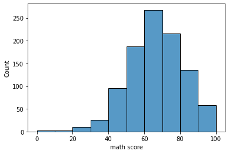

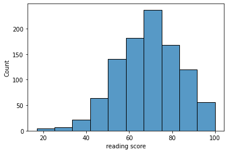

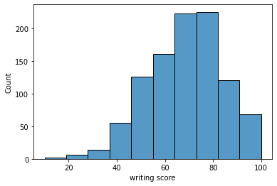

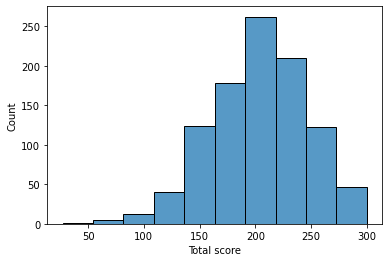

```python
%matplotlib inline
# 3. (a) Draw histograms of both numeric and non-numeric columns.

# Load all the libraries
import matplotlib.pyplot as plt
import seaborn as sns

# Identify numeric columns
num_columns = df.select_dtypes(exclude='object').columns

for c in num_columns:
    plt.figure()
    sns.histplot(x=c,bins=10,data=df);
    plt.show()


## To draw a single column
# plt.figure()
# sns.histplot(x='math score',bins=10,data=df);
# plt.show()
```

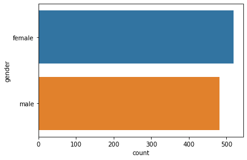

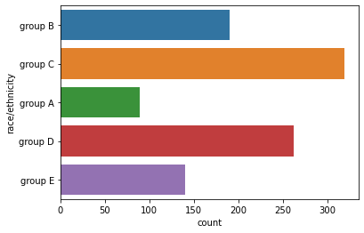

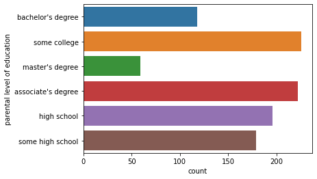

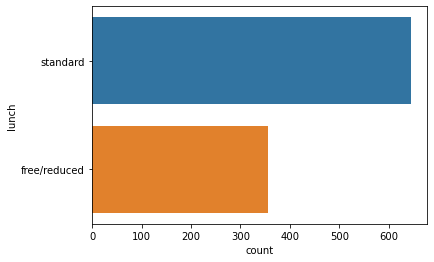

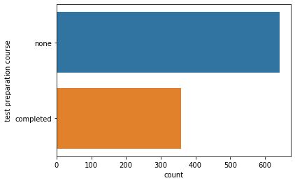

```python
# (b) For non-numeric columns, count plot option may be used.

# Identify non-numeric columns
obj_columns = df.select_dtypes('object').columns

# Plot for each identified column
for c in obj_columns:
    plt.figure()
#     sns.histplot(y=c,data=df);
    sns.countplot(y=c,data=df);
    plt.show()

## To draw a single column
# plt.figure()
# sns.countplot(y='gender',data=df);
# plt.show()
```

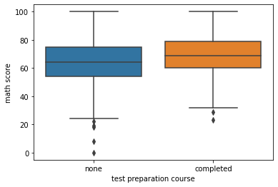

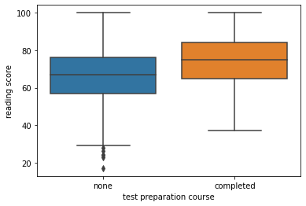

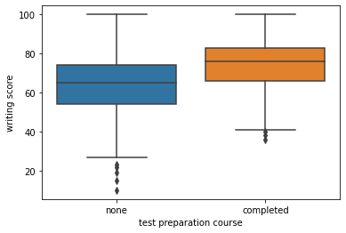

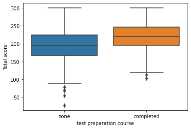

```python
# 4. Draw box-plots for the numeric columns, and differentiate by *test preparation course* column.

import matplotlib.pyplot as plt
import seaborn as sns

# Identify numeric columns
num_columns = df.select_dtypes(exclude='object').columns

for c in num_columns:
    plt.figure()
    sns.boxplot(y=c,x='test preparation course',data=df);
    plt.show()


# plt.figure()
# sns.boxplot(y='math score',x='test preparation course',data=df);
# plt.show()
```

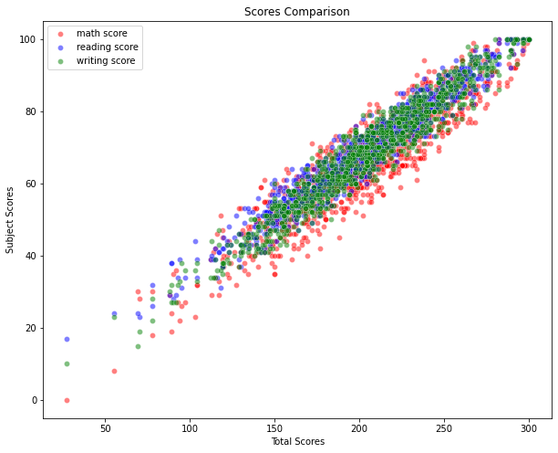

```python
# 5. Draw three overlapping scatter plots of columns *math score, reading score* and *writing score*
#w.r.t *Total score*. Set the markers transparency level (alpha) to 0.5.


plt.figure(figsize=(10,8))
sns.scatterplot(x='Total score', y='math score', color='red', label='math score',  alpha=0.5, data=df)
sns.scatterplot(x='Total score', y='reading score',color='blue',label='reading score', alpha=0.5, data=df)
sns.scatterplot(x='Total score', y='writing score',color='green',label='writing score', alpha=0.5, data=df)
plt.ylabel("Subject Scores");
plt.xlabel("Total Scores");
plt.title("Scores Comparison");
plt.show()
```

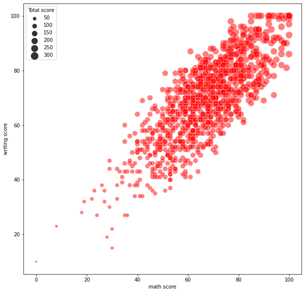

```python
# 6. Draw scatter plot of columns *math score* and *writing score*,
#where the size of the marker is based on column *Total score*.
#In addition to that, reduce the marker transparency (alpha) to 0.5.

plt.figure(figsize=(10,10))
sns.scatterplot(x='math score', y='writing score',
                size='Total score',sizes=(20,200),
                alpha=0.5, color='red',
                data=df)
plt.show()
```

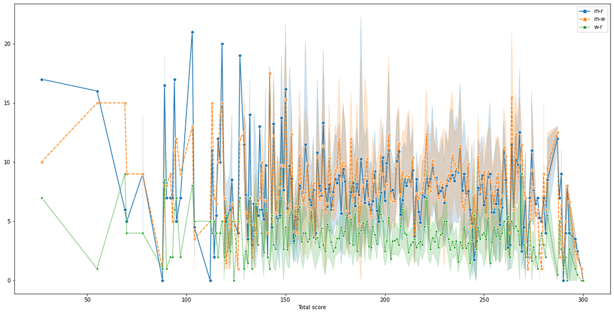

```python
# 7. Plot *Total score* in ascending order on the x axis,
# and the corresponding pairwise absolute differences of *math score, reading score* and *writing score*
# on the y axis.

# add new columns
df['m-r']=np.abs(df['math score']-df['reading score'])
df['m-w']=np.abs(df['math score']-df['writing score'])
df['w-r']=np.abs(df['writing score']-df['reading score'])

# select the data
sel_columns=['m-r','m-w','w-r','Total score']
ndf = df.loc[:,sel_columns]
ndf.set_index('Total score',inplace=True)
ndf.sort_index(inplace=True)
# display(ndf.head())

plt.figure(figsize=(20,10))
sns.lineplot(markers=True, data=ndf) #the plot `y values at each value of x and shows an estimate of the central tendency and a confidence interval for that estimate
plt.show()

# # the same plot can be made using the following code:
# plt.figure(figsize=(20,10))
# sns.lineplot(y='m-r',x='Total score', data=df)
# sns.lineplot(y='m-w',x='Total score', data=df)
# sns.lineplot(y='w-r',x='Total score', data=df)
# plt.show()

## Or to display the points without line
# plt.figure(figsize=(20,10))
# sns.scatterplot(data=ndf)
# plt.show()
```

### Example: Seaborn's Advanced Plots

**Question-C:** Consider the data in file Basic-4-Clean.csv.

1. Read and display information the data. Remove all rows containing NA values.
2. Depict *Category* column by count. In another plot, depict *Category* counts (differentiated) by *Type*.
3. Draw a boxplot plot of *Installs* vs *Rating* columns, ordered by *Installs*.
4. Draw a violinplot plot of *Content Rating* vs *Rating* columns, differentiated w.r.t *Type* .
5. Plot a barplot depicting count of *Category* that have *Installs* above 0.5B.
6. Depicting the *Size* of *Category* that have *Installs* above 0.5B.
7. For all the paid apps, depict *Genres* by count diferentiated by *Content Rating*. In another plot depict *Genres* by *Rating*.

```python
# 1. Read and display information the data. Remove all rows containing NA values.

import pandas as pd
df = pd.read_csv('data/Basic-4-Clean.csv')
print(df.info())
# print(df.shape)# Can also be obtained from info
# print(df.count())# Can also be obtained from info
display(df.sample(5))
```

```
<class 'pandas.core.frame.DataFrame'>
RangeIndex: 7723 entries, 0 to 7722
Data columns (total 13 columns):
 #   Column          Non-Null Count  Dtype
---  ------          --------------  -----
 0   App             7723 non-null   object
 1   Category        7723 non-null   object
 2   Rating          7723 non-null   float64
 3   Reviews         7723 non-null   int64
 4   Size            7723 non-null   float64
 5   Installs        7723 non-null   object
 6   Type            7723 non-null   object
 7   Price           7723 non-null   float64
 8   Content Rating  7723 non-null   object
 9   Genres          7723 non-null   object
 10  Last Updated    7723 non-null   object
 11  Current Ver     7723 non-null   object
 12  Android Ver     7723 non-null   object
dtypes: float64(3), int64(1), object(9)
memory usage: 784.5+ KB
None
```

|  | App | Category | Rating | Reviews | Size | Installs | Type | Price | Content Rating | Genres | Last Updated | Current Ver | Android Ver |
| --- | --- | --- | --- | --- | --- | --- | --- | --- | --- | --- | --- | --- | --- |
| 3808 | I am Bread | GAME | 4.0 | 630 | 20000.0 | 10000+ | Paid | 4.99 | Everyone | Adventure | 26-Oct-16 | 1.6.1 | 4.4 and up |
| 2773 | codeEazy - C/C++/JAVA | FAMILY | 4.6 | 130 | 2.2 | 10000+ | Free | 0.00 | Everyone | Education | 4-Apr-16 | 1.0.3 | 4.0.3 and up |
| 33 | How to draw Ladybug and Cat Noir | ART_AND_DESIGN | 3.8 | 564 | 9.2 | 100000+ | Free | 0.00 | Everyone | Art & Design | 11-Jul-18 | 2.1 | 4.1 and up |
| 138 | English translation from Bengali | BOOKS_AND_REFERENCE | 4.5 | 527 | 2.9 | 100000+ | Free | 0.00 | Everyone | Books & Reference | 31-Mar-18 | 14 | 4.0 and up |
| 406 | Black White Interracial Dating - Interracial M... | DATING | 4.1 | 537 | 28000.0 | 100000+ | Free | 0.00 | Mature 17+ | Dating | 29-Mar-18 | 2.0.0 | 4.1 and up |

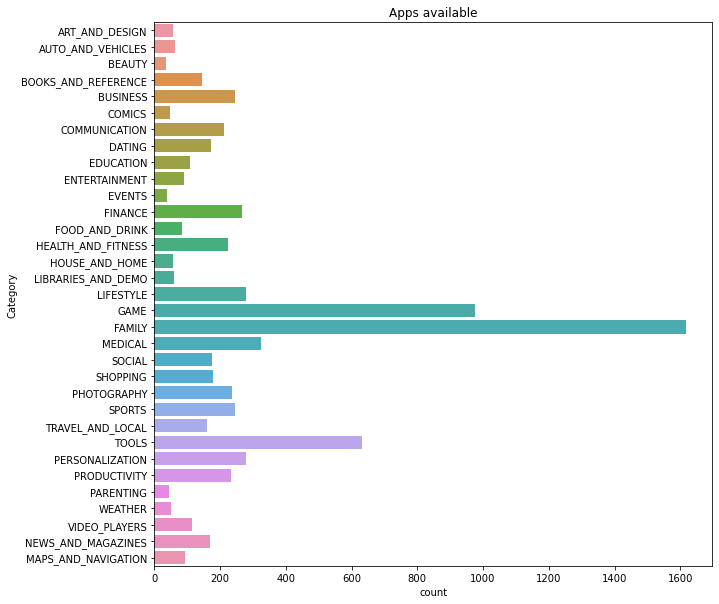

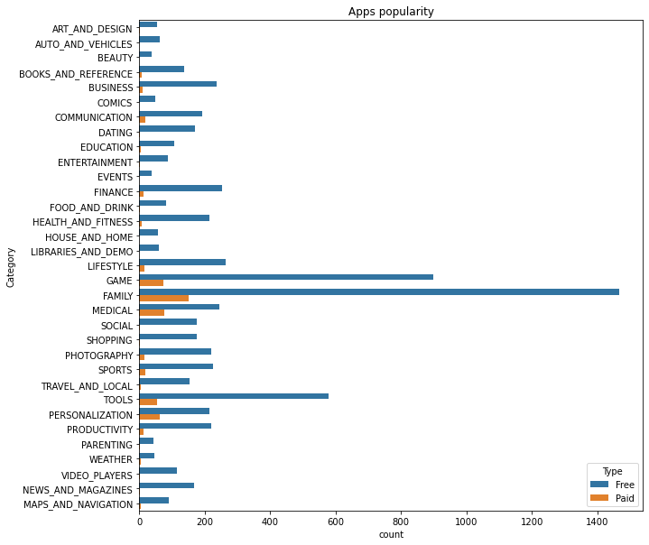

```python
# 2. Depict *Category* column by count. In another plot, depict *Category* counts (differentiated) by *Type*.

#plot category counts
import seaborn as sns
plt.figure(figsize=(10,10))
ax = sns.countplot(y="Category", data=df)
plt.title('Apps available')
plt.show()

#plot category with type
import seaborn as sns
plt.figure(figsize=(10,10))
ax = sns.countplot(y='Category',hue='Type',data=df)
plt.title('Apps popularity')
plt.show()
```

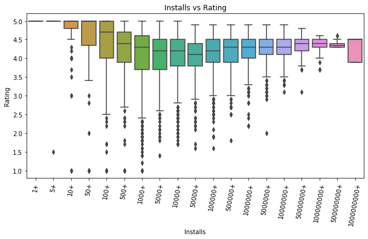

```python
#3. Draw a boxplot plot of *Installs* vs *Rating* columns, ordered by *Installs*.

#adding a new column
df['Installs_num']=df['Installs'].apply(lambda x:x.replace('+','')).apply(pd.to_numeric)

#the box plot
ax = plt.figure(figsize=(10,5))
sns.boxplot(x="Installs", y="Rating", data=df.sort_values(by=['Installs_num']))
plt.title("Installs vs Rating")
plt.xticks(rotation=80)
plt.show()
```

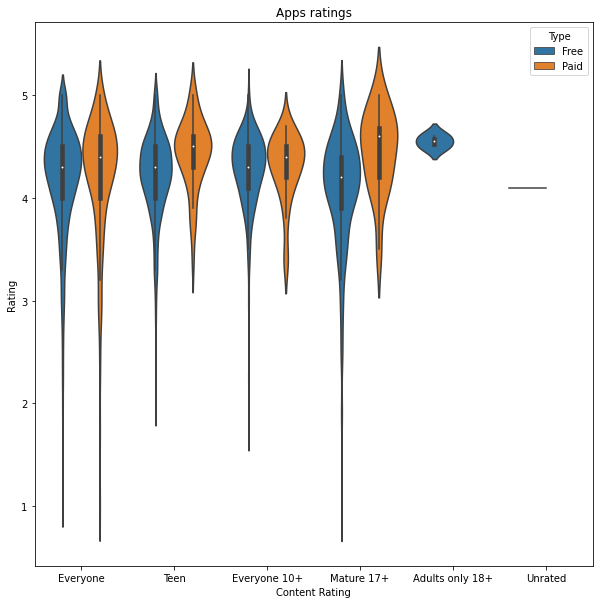

```python
#4. Draw a violinplot plot of *Content Rating* vs *Rating* columns, differentiated w.r.t *Type* .

import seaborn as sns
plt.figure(figsize=(10,10))
sns.violinplot(x ='Content Rating', y ='Rating', hue='Type', data = df)
plt.title('Apps ratings')
plt.show()
#violinplot plot also depitcs the distribution.


# # contrast with box plots
# plt.figure(figsize=(10,10))
# sns.boxplot(x ='Content Rating', y ='Rating', hue='Type', data = df)
# plt.title('Apps ratings')
# plt.show()
```

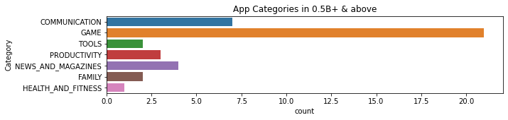

```python
#5. Plot a barplot depicting count of *Category* that have *Installs* above 0.5B.
import seaborn as sns
seleted_rows = (df['Installs']=='1000000000+') | (df['Installs']=='500000000+')

plt.figure(figsize=(10,2))
sns.countplot(y ='Category', data = df.loc[seleted_rows,:])
plt.title('App Categories in 0.5B+ & above')
plt.show()
```

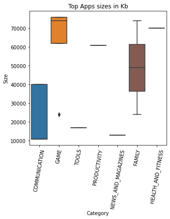

```python
#6. Depicting the *Size* of *Category* that have *Installs* above 0.5B.

import seaborn as sns

plt.figure(figsize=(5,5))
# ax=sns.swarmplot(x ='Category', y ='Size', data = df.loc[seleted_rows,:])
# ax=sns.violinplot(x ='Category', y ='Size', data = df.loc[seleted_rows,:])
ax=sns.boxplot(x ='Category', y ='Size', data = df.loc[seleted_rows,:])
plt.xticks(rotation=80)
plt.title('Top Apps sizes in Kb')
plt.show()
```

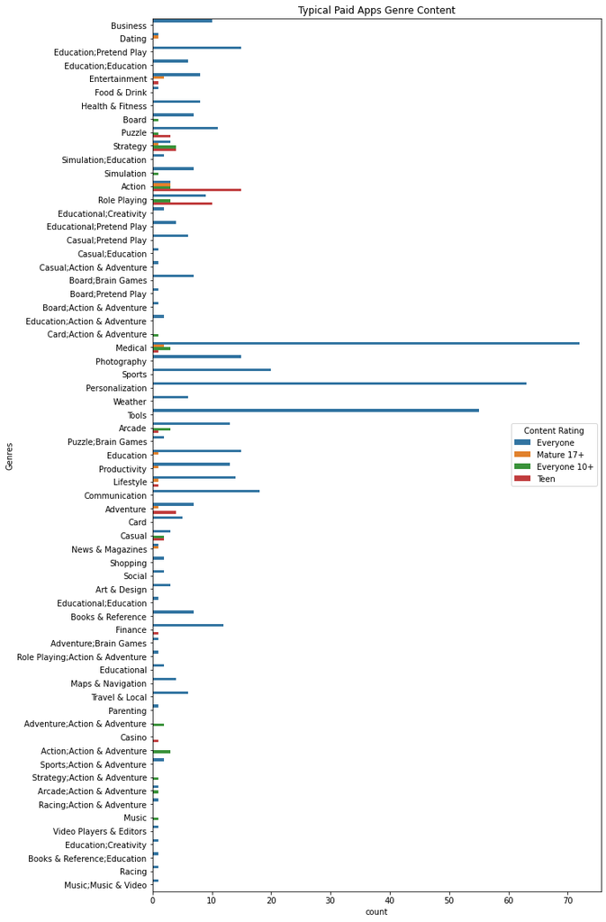

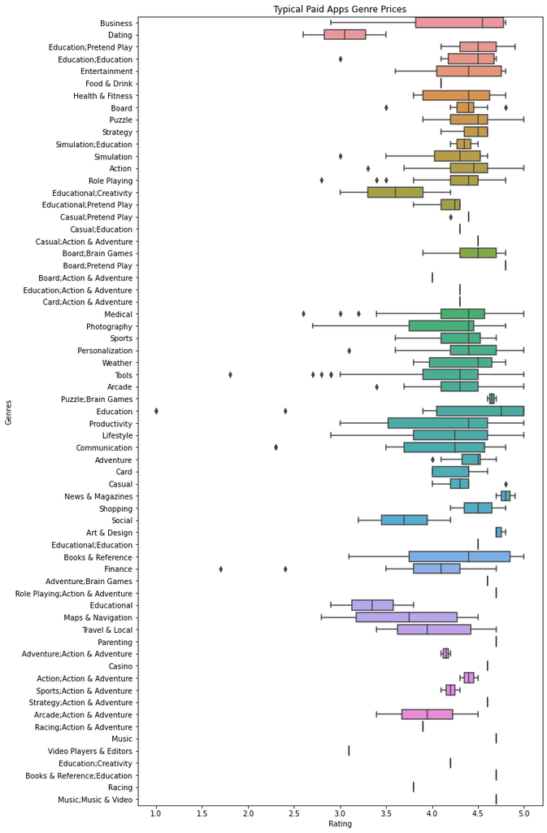

```python
# 7. For all the paid apps, depict *Genres* by count  diferentiated by *Content Rating*.
# In another plot depict *Genres* by *Rating*.

import seaborn as sns
seleted_rows = df['Type']=='Paid'

plt.figure(figsize=(10,20))
sns.countplot(y ='Genres',hue='Content Rating',data = df.loc[seleted_rows,:])
plt.title('Typical Paid Apps Genre Content')
plt.show()


plt.figure(figsize=(10,20))
sns.boxplot(y ='Genres',x='Rating',data = df.loc[seleted_rows,:])
plt.title('Typical Paid Apps Genre Prices')
plt.show()
```

# References:

## Data Sets:

1. Basic-2: Labor Relations Data, UCI Machine Learning Repository [http://archive.ics.uci.edu/ml]. Irvine, CA: University of California, School of Information and Computer Science. Published in: Bergadano, F., Matwin, S., Michalski, R., Zhang, J., Measuring Quality of Concept Descriptions, Procs. of the 3rd European Working Sessions on Learning, Glasgow, October 1988.
2. Basic-3: https://www.kaggle.com/spscientist/students-performance-in-exams
3. Basic-4: *modified*, https://www.kaggle.com/lava18/google-play-store-apps

## Others:

1. Series: https://pandas.pydata.org/pandas-docs/stable/reference/api/pandas.Series.html 📃
2. DataFrames: https://pandas.pydata.org/pandas-docs/stable/reference/frame.html 📃
3. Read CSV: https://pandas.pydata.org/pandas-docs/stable/reference/api/pandas.read_csv.html 📃
4. Read XLSX: https://pandas.pydata.org/pandas-docs/stable/reference/api/pandas.read_excel.html 📃
5. Visualization: https://pandas.pydata.org/pandas-docs/stable/user_guide/visualization.html 📃
6. Seaborn: https://seaborn.pydata.org/ 📃